# SPR 2023: Meta-Analysis Hands-on Demo in R

Maria Schweer-Collins

2023-05-30

## Hands on Demo

### Import depression outcomes data

```r
depression_symptoms <- import(here("data", "depression_symptoms.csv"))


### You should have 40 observations/studies
```

### Run random-effects meta-analysis

```r
depression_re <- rma(yi, vi, data = depression_symptoms, method="REML", knha=TRUE)
depression_re
```

```
##
## Random-Effects Model (k = 40; tau^2 estimator: REML)
##
## tau^2 (estimated amount of total heterogeneity): 0.2109 (SE = 0.0569)
## tau (square root of estimated tau^2 value):      0.4592
## I^2 (total heterogeneity / total variability):   92.39%
## H^2 (total variability / sampling variability):  13.15
##
## Test for Heterogeneity:
## Q(df = 39) = 260.8581, p-val < .0001
##
## Model Results:
##
## estimate      se     tval  df    pval    ci.lb    ci.ub
##  -0.3062  0.0800  -3.8272  39  0.0005  -0.4680  -0.1444  ***
##
## ---
## Signif. codes:  0 '***' 0.001 '**' 0.01 '*' 0.05 '.' 0.1 ' ' 1
```

```r
# obtain prediction intervals using predict function

predict(depression_re)
```

```
##
##     pred     se   ci.lb   ci.ub   pi.lb  pi.ub
##  -0.3062 0.0800 -0.4680 -0.1444 -1.2490 0.6366
```

### Visualize the results with a forest plot

Forest plots show the study-level and overall effect estimates and the precision with which those effects were estimated, but do not typically indicate the range of true effects (the prediction interval for the overall effect size estimate). When the prediction interval is incorporated, the forest plot presents both sources of variation in the overall effect size estimate – within-study error (the confidence interval for each study’s estimated effect) and true between-study heterogeneity – and therefore displays a more comprehensive summary of the important characteristics of a meta-analysis. A 95% prediction interval is included in a forest plot by using the addcred = TRUE argument, and is denoted by the gray bounding lines around the overall effect size estimate (the diamond-shaped indicator). The width of the indicator itself corresponds to the 95% confidence interval of the overall effect size estimate.

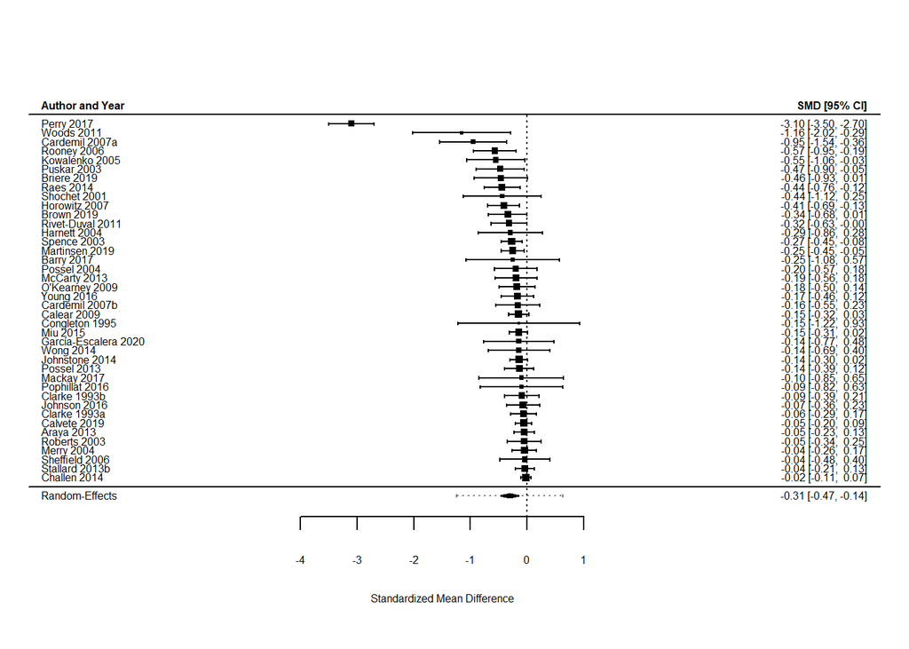

```r
forest(depression_re,
          header=c("Author and Year", "SMD [95% CI]"),
          mlab="Random-Effects",
          addcred = TRUE,
          order = yi,
          cex = .5,
          xlab = "Standardized Mean Difference",
          slab = depression_symptoms$study)
```